# 4.1.1

## 4.1.1 多维数组对象ndarray

NumPy的核心是ndarray对象。ndarray对象是封装了相同数据类型的n维数组，可以表示一维数组、二维数组甚至多维数组。访问ndarray对象的属性值，可以获取数组的维数、形状、元素个数、数据类型等数据，narray对象的常用属性如下表4-1-1所示。

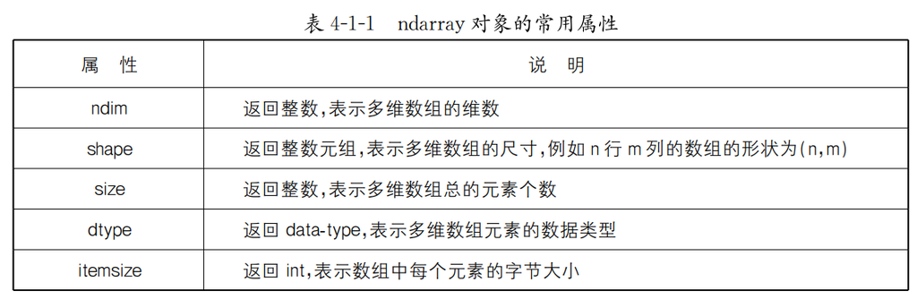

### 1. 创建多维数组对象

#### （1）一维数组对象的创建

- 调用array()函数创建一维数组

使用NumPy中的array()函数可以基于Python列表创建一维数组，其格式如下所示：

numpy.array(object, dtype=None, ndmin=0)

其中，object表示可被转换成数组的其它数据对象，例如列表；dtype表示数组所需的数据类型；ndmin为指定生成数组的维数。

**例4-1-1** 创建一个名为persons的一维数组对象，存储'宋江'、'吴用'、'林冲'和'秦明'这4位水浒传英雄的名字。查看persons对象的属性

```python
import numpy as np
```

```python
persons=np.array(['宋江','吴用','林冲','秦明'])
```

```python
persons
```

```
array(['宋江', '吴用', '林冲', '秦明'], dtype='<U2')
```

```python
___________ #查看persons对象的维度数目
```

```
1
```

```python
___________ #查看persons对象的尺寸
```

```
4
```

```python
___________ #查看persons对象的数据类型
```

```
dtype('<U2')
```

- 调用arange ()函数创建一维数组

使用NumPy中的arange ()函数可以生成数组，其格式如下所示：

numpy.arange([start,] stop[, step,], [step,]dtype=None)

与Python中内置函数range()用法类似，numpy.arange()函数的参数start表示开始的数字，stop表示结束的数字，但不包括stop，step表示步长的数字。

**例4-1-2** 示例使用arange函数生成一维数组对象，查看对象的数据类型，注意与range函数不同，arange函数支持float数据类型。

```python
num1=np.arange(__________) #生成【1-9】范围，间隔为1的整数数组
```

```python
____________  #查看num1对象的数据类型
```

```
dtype('int32')
```

```python
num2=np.arange(1.0,10.0)
```

```python
num2.dtype  #查看num2对象的数据类型
```

```
dtype('float64')
```

```python
num1
```

```
array([1, 2, 3, 4, 5, 6, 7, 8, 9])
```

```python
num2
```

```
array([1., 2., 3., 4., 5., 6., 7., 8., 9.])
```

- 调用linspace()函数创建一维数组

使用NumPy中的linspace()函数可以创建等间隔一维数组，它的常用格式如下所示：

numpy.linspace(start,stop,num=50,…)

其中，start代表起始的值；表示结束的值；num表示在这个区间里生成数字的个数，生成的数组是等间隔生成的。start和stop这两个数字可以是整数或者浮点数。注意区分stop参数在numpy.linspace()与numpy.arange()函数用法上的差异，默认情况下，生成的数组元素包括stop。

**例4-1-3** 示例使用linspace()函数创建三个等间隔的一维数组对象。

```python
np.linspace(_____________) #创建[1-10]间的间隔为3的数组
```

```
array([ 1.,  4.,  7., 10.])
```

```python
np.linspace(______________) #创建[1-10]间等间隔的含6个元素的数组
```

```
array([ 1. ,  2.8,  4.6,  6.4,  8.2, 10. ])
```

```python
np.linspace(______________) #创建如下所示等间隔的数组
```

```
array([ 2.5       ,  4.35714286,  6.21428571,  8.07142857,  9.92857143,
       11.78571429, 13.64285714, 15.5       ])
```

#### （2）二维数组对象的创建

- 调用array()函数创建二维数组

NumPy中的array()函数也可以基于Python的嵌套列表创建二维数组。

**例4-1-4** 创建一个记录三位同学语、数、英三门课程的二维NumPy数组对象，查看数组对象的属性。

```python
scores=np.array([[96,73,78],[90,89,92],[60,70,83]])
```

```python
scores
```

```
array([[96, 73, 78],
       [90, 89, 92],
       [60, 70, 83]])
```

```python
___________ #查看scores对象的维度数目
```

```
2
```

```python
___________ #查看scores对象的尺寸
```

```
9
```

```python
___________ #查看scores对象的数组形状
```

```
(3, 3)
```

```python
___________ #查看scores对象的数据类型
```

```
dtype('int32')
```

#### （3）创建多维数组的常用方法

Numpy库还提供了一些数组创建函数，以满足不同维度，不同需求。

- 调用reshape()函数创建多维数组

ndarray对象的reshape()函数用于将一维数组转换为指定的多维数组，其格式如下所示：

ndarray.reshape(newshape,...)

其中newshape表示新数组的形状，newshape的类型为整数或者整数元组。

reshape()函数经常与arange()函数结合使用，生成任意n维数组。

**例4-1-5** 创建一个形状为2×3×4的三维数组对象num_reshape。

```python
num=np.arange(0,24,1) #创建0到23的步长为1的一维数组
```

```python
num_reshape=num.reshape(____________) #转换为2 x 3 x 4的三维数组
```

```python
num_reshape
```

```
array([[[ 0,  1,  2,  3],
        [ 4,  5,  6,  7],
        [ 8,  9, 10, 11]],

       [[12, 13, 14, 15],
        [16, 17, 18, 19],
        [20, 21, 22, 23]]])
```

- 调用zeros()函数创建多维数组

NumPy中的zeros()函数用于生成指定形状的全0数组，其格式如下所示：

numpy.zeros(shape,…)

其中，shape表示新的数组形状，shape的类型为整数或者整数元组。

**例4-1-6** 创建一个3×2，元素都为0的二维数组对象num。

```python
num=np._____________ #创建一个3×2，元素都为0的二维数组
```

```python
num
```

```
array([[0., 0.],
       [0., 0.],
       [0., 0.]])
```

- 调用ones()函数创建多维数组

NumPy中的ones()函数用于生成指定形状的全1数组，其格式如下所示：

numpy.ones(shape,…)

其中，shape表示新的数组形状，shape的类型为整数或者整数元组。

**例4-1-7** 创建一个3×2，元素都为1的二维数组对象num。

```python
num=np.___________ 创建一个3×2，元素都为1的二维数组
```

```python
num
```

```
array([[1., 1.],
       [1., 1.],
       [1., 1.]])
```

- 调用eye()函数创建多维数组

NumPy中的eye()函数用于生成指定维数的单位矩阵。所谓单位矩阵是指对角线元素都为1，其他元素都为0的方阵。由于在数学中单位矩阵一般用“I”表示，因此NumPy中采用了同音的eye单词作为函数名称。eye()函数格式如下所示：

numpy.eye(N, M,…)

其中，N表示输出数组的行数，M表示输出数组的列数。

**例4-1-8** 创建一个维度为3的单位矩阵数组对象num。

```python
num=np.__________ #创建一个维度为3的单位矩阵数组
```

```python
num
```

```
array([[1., 0., 0.],
       [0., 1., 0.],
       [0., 0., 1.]])
```

- 调用随机函数创建多维数组

表4-1-2提供了NumPy中常用随机函数。其中，size可以是一个整数，定义一维数组的长度，也可以是一个元组，定义一个二维数组的形状。

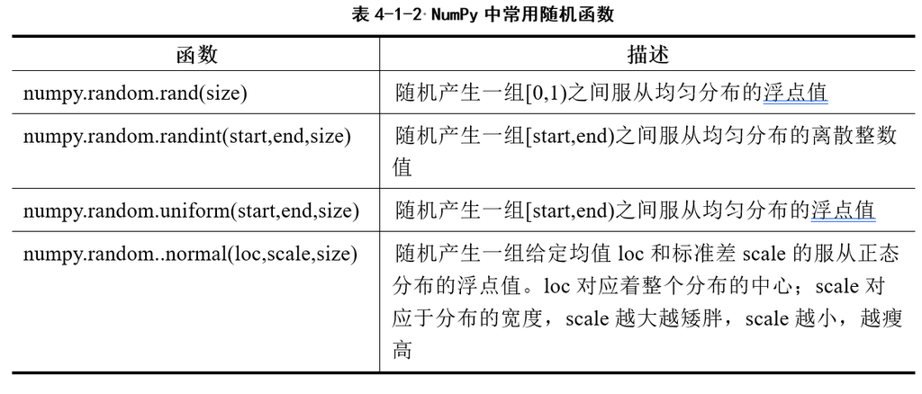

**例4-1-9** 使用随机函数创建数组示例。

# 创建一个2行、2列的[0,1)之间的随机数组

```python
arr1=np.______________ #创建一个2行、2列的[0,1)之间的随机数组（数值可与下例不一致）
```

```python
arr1
```

```
array([[0.97450436, 0.51136692],
       [0.42350645, 0.86004515]])
```

# 创建一个2行、3列的[0,10)之间的随机数组

```python
arr2=np.________________  #创建一个2行、3列的[0,10)之间的随机整数数组（数值可与下例不一致）
```

```python
arr2
```

```
array([[4, 8, 2],
       [6, 2, 1]])
```

# 创建一个3行、4列的[1,2)之间的服从均匀分布的随机数组

```python
arr3=np.____________________ #创建一个3行、4列的[1,2)之间的服从均匀分布的随机数组（数值可与下例不一致）
```

```python
arr3
```

```
array([[1.79499501, 1.80873949, 1.69761431, 1.09904931],
       [1.1572993 , 1.84023701, 1.62368693, 1.75183113],
       [1.3513896 , 1.99152521, 1.42342451, 1.21964518]])
```

# 创建一个2行、3列的服从标准正态分布的随机数组

```python
arr4=np.____________________ #创建一个2行、3列的服从标准正态分布的随机数组（数值可与下例不一致）
```

```python
arr4
```

```
array([[ 0.32936634,  0.19723827,  2.01196735],
       [-0.53106596, -0.48528362,  0.14563632]])
```

### 2. 数组元素的访问

#### （1）通过索引方式进行查询

每一个数组元素都是由一个整数值或整数元组标识，称为索引或下标。通过索引可以获取对应的数组元素。可以一次访问一个数组元素，也可以通过行、列索引值列表访问多个数组元素。

**例4-1-10** 访问一维数组对象persons和persons中的数组元素。

```python
persons  #显示persons对象
```

```
array(['宋江', '吴用', '林冲', '秦明'], dtype='<U2')
```

```python
_____________   #取索引值为2的元素，得到字符串对象
```

```
'林冲'
```

```python
_____________  #取索引值为0和2的元素，得到数组对象
```

```
array(['宋江', '林冲'], dtype='<U2')
```

**例4-1-11** 访问二维数组scores和和scores中的数组元素。

```python
scores   #显示scores对象
```

```
array([[96, 73, 78],
       [90, 89, 92],
       [60, 70, 83]])
```

```python
________________   #取索引值为（1，0）的数组元素
```

```
90
```

```python
________________  #取索引值为（0，0），（0，2）的数组元素，返回数组
```

```
array([96, 78])
```

```python
________________  #取索引值为（0，0），（1，2）的数组元素，返回数组
```

```
array([96, 92])
```

#### （2）通过切片方式进行查询

**例4-1-12** 切片访问persons中的数组元素

```python
_____________    #取索引值大于等于2的元素
```

```
array(['林冲', '秦明'], dtype='<U2')
```

```python
_____________    #取索引值从1到2的元素
```

```
array(['吴用', '林冲'], dtype='<U2')
```

**例4-1-13** 切片访问scores对象中的数组元素。

```python
_____________  #取行索引值和列索引值都为大于等于1的元素
```

```
array([[89, 92],
       [70, 83]])
```

```python
_____________  #取行列索引值从1到2的所有行的元素
```

```
array([[73, 78],
       [89, 92],
       [70, 83]])
```

**例4-1-14** 同时使用索引值和切片方式访问scores对象。

```python
_____________  #取列索引值为0和2的元素
```

```
array([[96, 78],
       [90, 92],
       [60, 83]])
```

#### （3）通过布尔运算方式进行查询

ndarry对象可以通过布尔运算方式获取满足布尔表达式的元素。布尔表达式可以由关系运算构造，多个条件使用&（与）、|（或）、~（非）连接。

**例4-1-15** 使用布尔运算式查询scores对象中高于90或者低于80的成绩。

mask是用于筛选的布尔数组，具有与访问数组相同的行数和列数，布尔表达式计算结果为True或False，使用布尔数组就能筛选出符合条件的数组元素。也可以不产生mask数组，在scores数组的方括号中直接使用布尔表达式。

```python
scores
```

```
array([[96, 73, 78],
       [90, 89, 92],
       [60, 70, 83]])
```

```python
mask=___________________ #scores对象中成绩高于90或者低于80分对应的布尔值数组
```

```python
mask
```

```
array([[ True,  True,  True],
       [False, False,  True],
       [ True,  True, False]])
```

```python
scores[mask]
```

```
array([96, 73, 78, 92, 60, 70])
```